# Barbell Lifts Recognition

## Synopsis

Development of inexpencive yet functional personal activity devices allows collecting a large amount of data, which can be used for determining types of the activity performed by a person in real-time. The activities could also be further classified for determining, if a certain activity is performed correctly or not.

The *Random Forests* method, even with a small number of trees produces stable predicting models for these activities, which can be used for introducing new real-time feedback functionality for assesssing exercises.

## Data Processing

The data being analyzed is a part of the **Human Activity Recognition** project by [Groupware@LES](http://groupware.les.inf.puc-rio.br/har), which analyzes the patterns in the data recorded by personal activity devices (such as *Jawbone Up*, *Nike FuelBand*, and *Fitbit*).

This data set, particularly, contains the activity information recorded while lifting a barbell. A key requirement for effective training to have a positive impact on cardio-respiratory fitness is a *proper technique*. At the same time, incorrect technique has been identified as the main cause of training injuries. The presence of a trainer may not always be possible due to cost and availability, thus using ambient or on-body sensors may be a promising approach to assessing exercises and to providing feedback on the quality of execution.

In this project, 6 participants were asked to perform barbell lifts *correctly* and *incorrecly* in 5 different ways, classified with letters A, B, C, D, and E. The participants were wearing accelerometers on the belt, forearm, arm, and dumbell itself.

### Reading the Data

The data sets are available on the course project site in two files: the [first one](https://d396qusza40orc.cloudfront.net/predmachlearn/pml-training.csv) containing the training observation already classified; the [second one](https://d396qusza40orc.cloudfront.net/predmachlearn/pml-testing.csv) is the testing data, which should be classified with the constructed model.

```r
TRAIN_URL <- 'https://d396qusza40orc.cloudfront.net/predmachlearn/pml-training.csv'
TEST_URL <- 'https://d396qusza40orc.cloudfront.net/predmachlearn/pml-testing.csv'
TRAIN_FILENAME <- 'pml-training.csv'
TEST_FILENAME <- 'pml-testing.csv'

if (!file.exists(TRAIN_FILENAME)) {
    download.file(TRAIN_URL, TRAIN_FILENAME, method='curl')
}
if (!file.exists(TEST_FILENAME)) {
    download.file(TEST_URL, TEST_FILENAME, method='curl')
}

train.data <- read.csv(TRAIN_FILENAME)
test.data <- read.csv(TEST_FILENAME)
```

The training data set contains 19622 observations of 160 variables. The testing data set contains 20 observations, which should be classified into one of 5 different ways oif performing barbell lifts using the model developed over the training data set.

### Predictors

The data set contains 160 variables, but not all of them will be used as predictors for building the model. Let’s find the ones, which may have prominent effect on the classification.

At first, let’s exclude the variables, which are not defined (have all `NA` values) in the testing data set, so they could not be used in the model to predict an outcome.

```r
vars <- names(which(sapply( test.data, function(x) !all(is.na(x)))))
```

We are also not interested in any *meta* variables, e.g. timestamps, participant names, etc.

```r
meta.vars <- c('X', 'user_name', 'new_window', 'num_window', 'problem_id',
               'raw_timestamp_part_1', 'raw_timestamp_part_2', 'cvtd_timestamp')
```

We will also exclude the variables with *zero* or *near zero variance*, because they do not give strong evidence towards a certain classification outcome.

```r
nzv.vars <- names(train.data)[nearZeroVar(train.data)]

vars <- vars[! vars %in% c(meta.vars, nzv.vars)]; vars
```

```
##  [1] "roll_belt"            "pitch_belt"           "yaw_belt"
##  [4] "total_accel_belt"     "gyros_belt_x"         "gyros_belt_y"
##  [7] "gyros_belt_z"         "accel_belt_x"         "accel_belt_y"
## [10] "accel_belt_z"         "magnet_belt_x"        "magnet_belt_y"
## [13] "magnet_belt_z"        "roll_arm"             "pitch_arm"
## [16] "yaw_arm"              "total_accel_arm"      "gyros_arm_x"
## [19] "gyros_arm_y"          "gyros_arm_z"          "accel_arm_x"
## [22] "accel_arm_y"          "accel_arm_z"          "magnet_arm_x"
## [25] "magnet_arm_y"         "magnet_arm_z"         "roll_dumbbell"
## [28] "pitch_dumbbell"       "yaw_dumbbell"         "total_accel_dumbbell"
## [31] "gyros_dumbbell_x"     "gyros_dumbbell_y"     "gyros_dumbbell_z"
## [34] "accel_dumbbell_x"     "accel_dumbbell_y"     "accel_dumbbell_z"
## [37] "magnet_dumbbell_x"    "magnet_dumbbell_y"    "magnet_dumbbell_z"
## [40] "roll_forearm"         "pitch_forearm"        "yaw_forearm"
## [43] "total_accel_forearm"  "gyros_forearm_x"      "gyros_forearm_y"
## [46] "gyros_forearm_z"      "accel_forearm_x"      "accel_forearm_y"
## [49] "accel_forearm_z"      "magnet_forearm_x"     "magnet_forearm_y"
## [52] "magnet_forearm_z"
```

### Exploratory Analysis of the Predictors

The exploratory analysis may be used for further reducing the number of the predictors to be used for building the model.

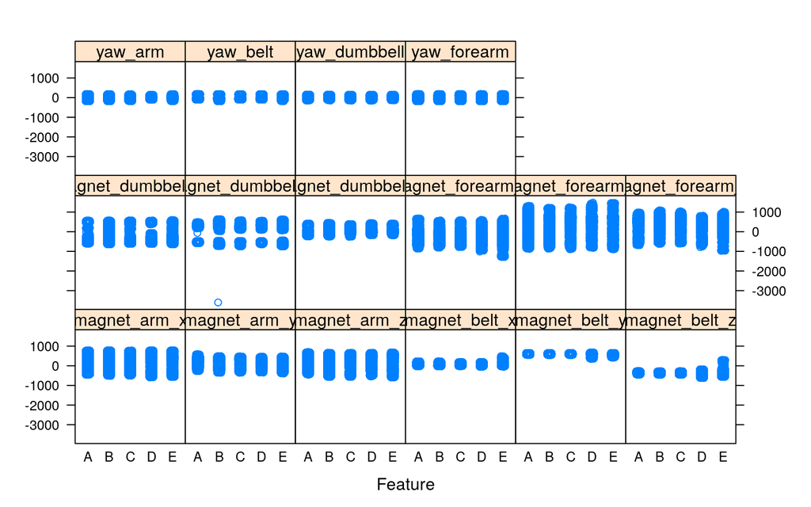

```r
featurePlot(x=train.data[, vars[grep('^(magnet|yaw)', vars)]],
            y= train.data$classe, 'strip', jitter=TRUE)
```

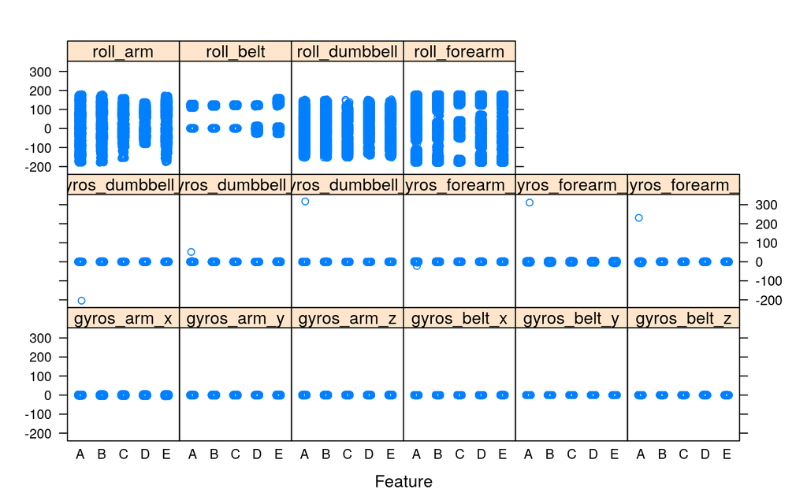

```r
featurePlot(x=train.data[, vars[grep('^(gyros|roll)', vars)]],
            y= train.data$classe, 'strip', jitter=TRUE)
```

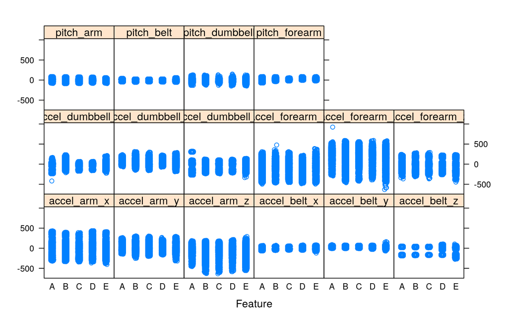

```r
featurePlot(x=train.data[, vars[grep('^(accel|pitch)', vars)]],
            y= train.data$classe, 'strip', jitter=TRUE)
```

Feature plots show little variance between the outcomes for gyroscope sensor data, so these variables will not be used as predictors.

```r
predictors <- c('yaw_belt', 'yaw_arm',
          vars[c(grep('^magnet', vars), grep('^accel', vars))])
```

## Building a Model

Since we are mainly interested in the final classification, rather then in the interpretability of the model, a decision tree learning seems to be an optimum choice. Particularly, the *Random Forests* method will be used.

A typical tree learning algorithm uses *bagging* (*bootstrap aggregating*), which can reduce the affect of the characteristic noise by averaging several trees built on subsets of the training data, thus, reducing the variance of the model.

The *Random Forests* method additionally introduces *feature bagging*, which randomly chooses a subset of predictors, at each split, so that different trees used in bootstraps do not share the same set of featers used and, therefore, are less correlated, reducing possible overfitting.

Before *growing* each tree in the forest, a training subset of the data is sampled with replacement, leaving about one-third out. This *oob* (out-of-bag) data is used to get an unbiased estimate of the classification error.

```r
# set random seed for reproducibility
set.seed(23413)

# create a formula out of predictors
f <- as.formula(paste('classe ~ ', paste(predictors, collapse='+')))

# train Random Forests models
fit1 <- train(f, data=train.data, method='rf', ntree=1); fit1$finalModel$confusion
```

```
##      A    B    C    D    E class.error
## A 2002   35   15   17    8  0.03610977
## B   53 1269   50   19   26  0.10444601
## C   11   55 1147   37   14  0.09256329
## D   31   27   34 1046   18  0.09515571
## E    9   37   17   25 1283  0.06418673
```

```r
fit5 <- train(f, data=train.data, method='rf', ntree=5); fit5$finalModel$confusion
```

```
##      A    B    C    D    E class.error
## A 4902   46   27   28   16  0.02331142
## B  149 3117   75   38   34  0.08672722
## C   58  152 2760   47   37  0.09626719
## D   71   69  113 2631   22  0.09463180
## E   37   99   62   53 3006  0.07706478
```

```r
fit10 <- train(f, data=train.data, method='rf', ntree=10); fit10$finalModel$confusion
```

```
##      A    B    C    D    E class.error
## A 5456   29   17   23    7  0.01373825
## B  110 3553   56   24   25  0.05705945
## C   44  100 3185   43   15  0.05963980
## D   49   32   92 2997   17  0.05961719
## E   21   60   37   35 3424  0.04277327
```

```r
fit20 <- train(f, data=train.data, method='rf', ntree=20); fit20$finalModel$confusion
```

```
##      A    B    C    D    E class.error
## A 5558   10    3    9    0 0.003942652
## B   53 3672   49   11   11 0.032665964
## C   13   61 3320   25    3 0.029807130
## D   16    7   64 3118    9 0.029869322
## E    5   21   15   17 3549 0.016079845
```

Even with the small number of *trees* in the *forest* used for bagging, the error rate is rather small. The trivial forest of only one tree yields 7.39% OOB error rate. The 5-tree models yields 6.99% OOB error rate. The 10 and 20-tree models yield 4.3% and 2.05% OBB error rates accordingly.

### Predicting the Testing Outcomes

We use the constructed Random Forests models for predicing the classification outcome of the *testing* data set.

```r
predict(fit1, newdata=test.data[])
```

```
##  [1] A A B A A C D B A A B C B A E E A B B B
## Levels: A B C D E
```

```r
predict(fit5, newdata=test.data[])
```

```
##  [1] B A B A A E D B A A B C B A E E A A B B
## Levels: A B C D E
```

```r
predict(fit10, newdata=test.data[])
```

```
##  [1] B A B A A E D B A A B C B A E E A B B B
## Levels: A B C D E
```

```r
predict(fit20, newdata=test.data[])
```

```
##  [1] B A B A A E D B A A B C B A E E A B B B
## Levels: A B C D E
```